# Which Demographics Are Most Likely To Utilize HUD To Purchase Low-Income Housing? And What Of Those Explored Demographics Require Assisted Units?

=====================================================================================================

**(Subsidized housing VS. Fully Paid housing)**

### Data Source

The data used in this analysis is sourced from Kaggle: [HUD Multifamily Housing Assisted Properties Data](https://www.kaggle.com/datasets/thedevastator/hud-multifamily-housing-assisted-properties-data/data)

### What is HUD?

The U.S. Department of Housing and Urban Development (HUD) is a government agency responsible for national policies and programs that address America's housing needs, improve and develop the nation's urban areas, and enforce fair housing laws. HUD provides various services, including assistance for low-income housing, homeownership programs, and community development initiatives.

### Why is this research useful?

This research is useful because it helps identify the demographics most likely to utilize HUD for low-income housing, enabling policymakers to allocate resources effectively and design targeted programs. Additionally, understanding which demographics require assisted units can inform community development initiatives and improve overall housing stability, ultimately enhancing the quality of life for vulnerable populations.

```python
import pandas as pd
data = pd.read_csv('lowincome_housing.csv')
data
```

|  | index | X | Y | OBJECTID | PROPERTY_ID | UGLG_KEY | HUB_NAME_TEXT | SERVICING_SITE_NAME_TEXT | PROJECT_MANAGER_NAME_TEXT | PROPERTY_NAME_TEXT | ... | TPOVERTY | TPCT_OWNSFD | CHLDRN_MBR_CNT | ELDLY_PRCNT | PCT_DISABLED_LT62_ALL | PCT_LT80_MEDIAN | MEDIAN_INC_AMNT | LAST_UPDT_DTTM | ANNL_EXPNS_AMNT | ANNL_EXPNS_AMNT_PREV_YR |
| --- | --- | --- | --- | --- | --- | --- | --- | --- | --- | --- | --- | --- | --- | --- | --- | --- | --- | --- | --- | --- | --- |
| 0 | 0 | -83.094242 | 40.309009 | 1 | 800000030 | 3921434.0 | Detroit | Detroit | DENISE WILLIAMS | DELAWARE CREATIVE HOUSING HUD II | ... | -4.000000 | -4.000000 | -4 | -4.000000 | -4.000000 | -4.0 | -4 | 2022/01/06 19:10:36+00 | -4 | -4.0 |
| 1 | 1 | -86.143070 | 41.652389 | 2 | 800000031 | 1849932.0 | Chicago | Chicago | GERALDINE V DUPATY | EASTGATE APARTMENTS | ... | 10.790000 | 90.260002 | 5 | 44.900002 | 22.450001 | 100.0 | 11640 | 2022/01/06 19:10:36+00 | 187156 | 180305.0 |
| 2 | 2 | -76.601014 | 39.309478 | 3 | 800000043 | 2404000.0 | Baltimore | Baltimore | CAROLYN M ANASTASI | QUEEN ESTHER / LANVALE TOWERS | ... | 31.400000 | 3.110000 | 60 | 12.560000 | 30.490000 | 100.0 | 9528 | 2022/01/06 19:10:36+00 | 1935342 | 1852369.0 |
| 3 | 3 | -86.347000 | 38.367692 | 4 | 800000045 | 1846746.0 | Chicago | Chicago | DAPHNE C LLOYD | LHDC MARENGO HOUSING FOR ELDERLY | ... | 16.160000 | 76.220001 | 1 | 79.169998 | 12.500000 | 100.0 | 12960 | 2022/01/06 19:10:36+00 | 210453 | 216625.0 |
| 4 | 4 | -87.703574 | 41.886009 | 5 | 800000046 | 1714000.0 | Chicago | Chicago | TANIKA MATHIS-EARSERY | MATTHEW MANOR | ... | 28.730000 | 11.100000 | 0 | 98.309998 | 0.000000 | 100.0 | 10304 | 2022/01/06 19:10:36+00 | 588277 | 596380.0 |
| ... | ... | ... | ... | ... | ... | ... | ... | ... | ... | ... | ... | ... | ... | ... | ... | ... | ... | ... | ... | ... | ... |
| 23629 | 23629 | -84.166541 | 31.585920 | 23630 | 800251092 | 1301052.0 | Atlanta | Atlanta | DEBRA A NEWMAN | Albany Phase I | ... | 61.240002 | 40.400002 | 30 | 22.969999 | 14.860000 | 100.0 | 9528 | 2022/01/06 19:10:36+00 | 652892 | 282749.0 |
| 23630 | 23630 | -106.344182 | 31.794893 | 23631 | 800251157 | 4824000.0 | Fort Worth | Fort Worth | QIANA DAVIS | HAYMON KRUPP MEMORIAL APTS (RAD) | ... | 23.190001 | 62.160000 | 24 | 14.890000 | 6.380000 | 100.0 | 9768 | 2022/01/06 19:10:36+00 | 52827 | 47650.0 |
| 23631 | 23631 | -79.373419 | 34.420285 | 23632 | 800250500 | 4519420.0 | Atlanta | Atlanta | NaN | DILLON GRADED SCHOOL | ... | -4.000000 | -4.000000 | -4 | -4.000000 | -4.000000 | -4.0 | -4 | 2022/01/06 19:10:36+00 | -4 | -4.0 |
| 23632 | 23632 | -72.309187 | 43.647435 | 23633 | 800250641 | 3341300.0 | Headquarters | Headquarters - BRSC | ANDREA HENDRICKS | Tracy Street Housing | ... | -4.000000 | -4.000000 | -4 | -4.000000 | -4.000000 | -4.0 | -4 | 2022/01/06 19:10:36+00 | -4 | -4.0 |
| 23633 | 23633 | -95.210993 | 29.664566 | 23634 | 800252395 | 4869020.0 | Headquarters | Headquarters - BRSC | ANDREA HENDRICKS | Windsor Gardens Apartments | ... | -4.000000 | -4.000000 | -4 | -4.000000 | -4.000000 | -4.0 | -4 | 2022/01/06 19:10:36+00 | -4 | -4.0 |

23634 rows × 287 columns

### All Selected columns ( and their definitions )

=====================================================================================================

```
- **PCT_MINORITY**: Percentage of the population that identifies as a racial or ethnic minority.
- **PCT_BLACK**: Percentage of the population that identifies as Black or African American.
- **PCT_NATIVE_AMERICAN**: Percentage of the population that identifies as Native American or Alaska Native.
- **PCT_ASIAN**: Percentage of the population that identifies as Asian.
- **PCT_HISPANIC**: Percentage of the population that identifies as Hispanic or Latino.
- **PCT_FEMALE_HEAD**: Percentage of households headed by a female without a male partner.
- **PCT_FEMALE_HEAD_CHILD**: Percentage of female-headed households with children.
- **PCT_DISABLED_LT62**: Percentage of the population with disabilities who are under 62 years old.
- **PCT_DISABLED_GE62**: Percentage of the population with disabilities who are 62 years old or older.
- **PCT_DISABLED_ALL**: Percentage of the total population with disabilities.
- **PCT_AGE25_50**: Percentage of the population aged 25 to 50 years.
- **PCT_AGE51_61**: Percentage of the population aged 51 to 61 years.
- **PCT_AGE62PLUS**: Percentage of the population aged 62 years and older.
- **PCT_AGE85PLUS**: Percentage of the population aged 85 years and older.
- **HH_INCOME**: Household income, typically reported as a total amount.
- **PERSON_INCOME**: Individual income, typically reported as a total amount.
- **PCT_LT5K**: Percentage of the population earning less than $5,000.
- **PCT_5K_LT10K**: Percentage of the population earning between $5,000 and $10,000.
- **PCT_10K_LT15K**: Percentage of the population earning between $10,000 and $15,000.
- **PCT_15K_LT20K**: Percentage of the population earning between $15,000 and $20,000.
- **PCT_GE20K**: Percentage of the population earning $20,000 or more.
- **PCT_LT50_MEDIAN**: Percentage of households earning less than 50% of the median income.
- **PCT_LT30_MEDIAN**: Percentage of households earning less than 30% of the median income.
- **MEDIAN_INC_AMNT**: The median income amount for the area.
- **TOTAL_ASSISTED_UNIT_COUNT**: Total number of housing units receiving assistance.
- **TOTAL_UNIT_COUNT**: Total number of housing units in the area.
- **RENT_PER_MONTH**: Average rent charged per month for housing units.
- **SPENDING_PER_MONTH**: Average monthly spending by households.
- **PCT_OCCUPIED**: Percentage of housing units that are occupied.
- **PEOPLE_PER_UNIT**: Average number of people living in each housing unit.
- **PEOPLE_TOTAL**: Total number of people living in the area.
```

### Why I filtered to these 31 columns:

===================================================================================================== These columns were selected because they provide detailed data on; income, disability status, household composition, age, and racial/ethnic identity, which are key factors influencing eligibility and the likelihood of utilizing HUD programs for low-income housing.

```python
# Select relevant columns
columns_to_keep = [
    'PCT_MINORITY', 'PCT_BLACK', 'PCT_NATIVE_AMERICAN', 'PCT_ASIAN',
    'PCT_HISPANIC', 'PCT_FEMALE_HEAD', 'PCT_FEMALE_HEAD_CHILD',
    'PCT_DISABLED_LT62', 'PCT_DISABLED_GE62', 'PCT_DISABLED_ALL',
    'PCT_AGE25_50', 'PCT_AGE51_61', 'PCT_AGE62PLUS', 'PCT_AGE85PLUS',
    'HH_INCOME', 'PERSON_INCOME', 'PCT_LT5K', 'PCT_5K_LT10K',
    'PCT_10K_LT15K', 'PCT_15K_LT20K', 'PCT_GE20K', 'PCT_LT50_MEDIAN',
    'PCT_LT30_MEDIAN', 'MEDIAN_INC_AMNT', 'TOTAL_ASSISTED_UNIT_COUNT',
    'TOTAL_UNIT_COUNT', 'RENT_PER_MONTH', 'SPENDING_PER_MONTH',
    'PCT_OCCUPIED', 'PEOPLE_PER_UNIT', 'PEOPLE_TOTAL'
]

# Create a new DataFrame with only the selected columns
filtered_data = data[columns_to_keep]
```

## Data Cleaning

=====================================================================================================

```python
# Select relevant columns
columns_to_keep = [
    'PCT_MINORITY', 'PCT_BLACK', 'PCT_NATIVE_AMERICAN', 'PCT_ASIAN',
    'PCT_HISPANIC', 'PCT_FEMALE_HEAD', 'PCT_FEMALE_HEAD_CHILD',
    'PCT_DISABLED_LT62', 'PCT_DISABLED_GE62', 'PCT_DISABLED_ALL',
    'PCT_AGE25_50', 'PCT_AGE51_61', 'PCT_AGE62PLUS', 'PCT_AGE85PLUS',
    'HH_INCOME', 'PERSON_INCOME', 'PCT_LT5K', 'PCT_5K_LT10K',
    'PCT_10K_LT15K', 'PCT_15K_LT20K', 'PCT_GE20K', 'PCT_LT50_MEDIAN',
    'PCT_LT30_MEDIAN', 'MEDIAN_INC_AMNT', 'TOTAL_ASSISTED_UNIT_COUNT',
    'TOTAL_UNIT_COUNT', 'RENT_PER_MONTH', 'SPENDING_PER_MONTH',
    'PCT_OCCUPIED', 'PEOPLE_PER_UNIT', 'PEOPLE_TOTAL'
]

# Checking for missing values
missing_values = filtered_data.isnull().sum()
print("Missing values:")
print(missing_values)

# Checking for duplicate rows
duplicate_rows = filtered_data.duplicated().sum()
print("Duplicate rows:")
print(duplicate_rows)

# Checking for inconsistent data types
print("Data types:")
print(filtered_data.dtypes)
```

```
Missing values:
PCT_MINORITY                 0
PCT_BLACK                    0
PCT_NATIVE_AMERICAN          0
PCT_ASIAN                    0
PCT_HISPANIC                 0
PCT_FEMALE_HEAD              0
PCT_FEMALE_HEAD_CHILD        0
PCT_DISABLED_LT62            0
PCT_DISABLED_GE62            0
PCT_DISABLED_ALL             0
PCT_AGE25_50                 0
PCT_AGE51_61                 0
PCT_AGE62PLUS                0
PCT_AGE85PLUS                0
HH_INCOME                    0
PERSON_INCOME                0
PCT_LT5K                     0
PCT_5K_LT10K                 0
PCT_10K_LT15K                0
PCT_15K_LT20K                0
PCT_GE20K                    0
PCT_LT50_MEDIAN              0
PCT_LT30_MEDIAN              0
MEDIAN_INC_AMNT              0
TOTAL_ASSISTED_UNIT_COUNT    0
TOTAL_UNIT_COUNT             0
RENT_PER_MONTH               0
SPENDING_PER_MONTH           0
PCT_OCCUPIED                 0
PEOPLE_PER_UNIT              0
PEOPLE_TOTAL                 0
dtype: int64
Duplicate rows:
2290
Data types:
PCT_MINORITY                 float64
PCT_BLACK                    float64
PCT_NATIVE_AMERICAN          float64
PCT_ASIAN                    float64
```

[output cut: 13 more lines]

```
PCT_5K_LT10K                 float64
PCT_10K_LT15K                float64
PCT_15K_LT20K                float64
PCT_GE20K                    float64
PCT_LT50_MEDIAN              float64
PCT_LT30_MEDIAN              float64
MEDIAN_INC_AMNT                int64
TOTAL_ASSISTED_UNIT_COUNT      int64
TOTAL_UNIT_COUNT               int64
RENT_PER_MONTH                 int64
SPENDING_PER_MONTH             int64
PCT_OCCUPIED                 float64
PEOPLE_PER_UNIT              float64
PEOPLE_TOTAL                   int64
dtype: object
```

```python
unique_values = data['HH_INCOME'].unique()
print(unique_values)
value_counts = data['HH_INCOME'].value_counts()
print(value_counts)
```

```
[   -4 11602 11262 ...  5735  1303  9825]
HH_INCOME
-4        4143
 12856      11
 12434      10
 11054       9
 11954       9
          ...
 18256       1
 26254       1
 11823       1
 8263        1
 9825        1
Name: count, Length: 10023, dtype: int64
```

```python
import pandas as pd
import numpy as np

data = {
    'HH_INCOME': [-4, 12856, 12434, 11054, 11954, 18256, 26254, 11823, 8263, 9825]
}
hh_income_series = pd.Series(data['HH_INCOME'])


#Remove negative values
cleaned_hh_income = hh_income_series[hh_income_series >= 0]

#Reset index
cleaned_hh_income = cleaned_hh_income.reset_index(drop=True)

# Display the cleaned data
print(cleaned_hh_income)
```

```
0    12856
1    12434
2    11054
3    11954
4    18256
5    26254
6    11823
7     8263
8     9825
dtype: int64
```

```python
unique_values = filtered_data['PCT_MINORITY'].unique()
print(unique_values)
value_counts = filtered_data['PCT_MINORITY'].value_counts()
print(value_counts)
```

```
[-4.        0.       90.849998 ... 48.049999 52.869999 89.199997]
PCT_MINORITY
-4.000000      4143
 0.000000      1365
 100.000000    1010
 8.330000       153
 25.000000      132
               ...
 26.870001        1
 75.629997        1
 47.169998        1
 85.900002        1
 89.199997        1
Name: count, Length: 3996, dtype: int64
```

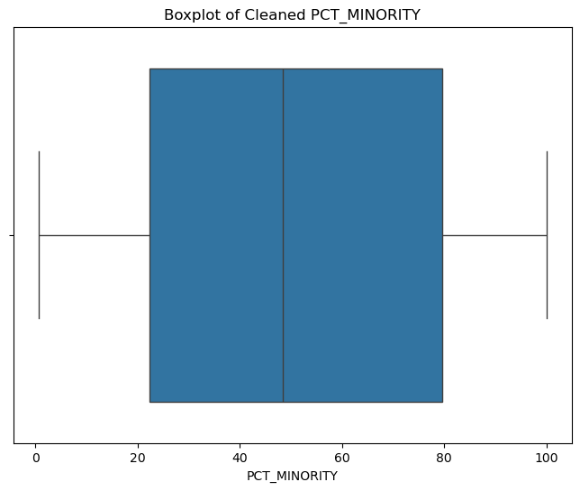

```
Cleaned Data Summary:
count    23634.000000
mean        50.394004
std         31.101026
min          0.680000
25%         22.309999
50%         48.480000
75%         79.645001
max        100.000000
Name: PCT_MINORITY, dtype: float64
```

```python
import pandas as pd
from scipy.stats import zscore
import seaborn as sns
import matplotlib.pyplot as plt

filtered_data['PCT_MINORITY'] = filtered_data['PCT_MINORITY'].replace(-4.0, pd.NA)

# Replacing 0.0 with NaN
filtered_data['PCT_MINORITY'] = filtered_data['PCT_MINORITY'].replace(0.0, pd.NA)

# Cap values to the range [0, 100]
filtered_data['PCT_MINORITY'] = filtered_data['PCT_MINORITY'].clip(lower=0, upper=100)

# Impute missing values with the median (or mean, depending on preference)
filtered_data['PCT_MINORITY'] = filtered_data['PCT_MINORITY'].fillna(filtered_data['PCT_MINORITY'].median())


plt.figure(figsize=(8, 6))
sns.boxplot(x=filtered_data['PCT_MINORITY'])
plt.title('Boxplot of Cleaned PCT_MINORITY')
plt.show()

# Final summary of the cleaned data
print(f"Cleaned Data Summary:\n{filtered_data['PCT_MINORITY'].describe()}")
```

```python
unique_values = filtered_data['PCT_BLACK'].unique()
print(unique_values)
value_counts = filtered_data['PCT_BLACK'].value_counts()
print(value_counts)
```

```
[-4.        0.       89.540001 ... 98.870003 17.1      27.200001]
PCT_BLACK
 0.000000      4252
-4.000000      4143
 100.000000     342
 8.330000       129
 9.090000       110
               ...
 73.940002        1
 53.419998        1
 9.729999         1
 82.790001        1
 27.200001        1
Name: count, Length: 3832, dtype: int64
```

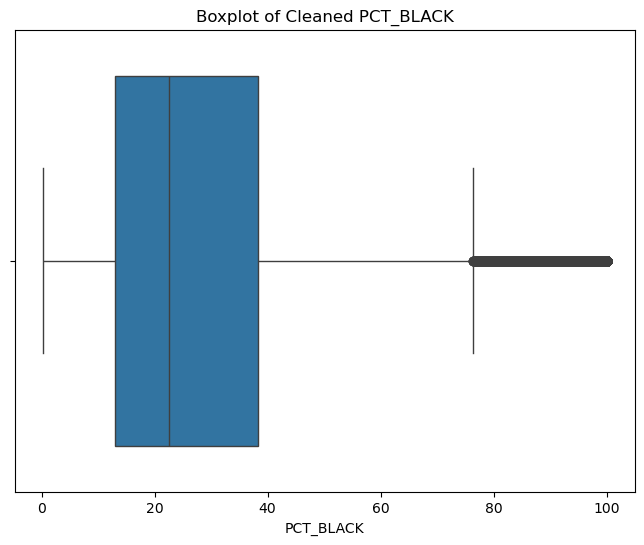

```
Cleaned Data Summary:
count    23634.000000
mean        31.543035
std         28.045977
min          0.260000
25%         12.960000
50%         22.500000
75%         38.292499
max        100.000000
Name: PCT_BLACK, dtype: float64
```

```python
import pandas as pd
from scipy.stats import zscore
import seaborn as sns
import matplotlib.pyplot as plt


# Replace -4.0 with NaN in the PCT_BLACK column
filtered_data['PCT_BLACK'] = filtered_data['PCT_BLACK'].replace(-4.0, pd.NA)

# Replace 0.0 with NaN (if zeros are invalid)
filtered_data['PCT_BLACK'] = filtered_data['PCT_BLACK'].replace(0.0, pd.NA)

#Cap values to the range [0, 100]
filtered_data['PCT_BLACK'] = filtered_data['PCT_BLACK'].clip(lower=0, upper=100)

#Impute missing values with the median
filtered_data['PCT_BLACK'] = filtered_data['PCT_BLACK'].fillna(filtered_data['PCT_BLACK'].median())

plt.figure(figsize=(8, 6))
sns.boxplot(x=filtered_data['PCT_BLACK'])
plt.title('Boxplot of Cleaned PCT_BLACK')
plt.show()
# Final summary of the cleaned data
print(f"Cleaned Data Summary:\n{filtered_data['PCT_BLACK'].describe()}")
```

```python
unique_values = filtered_data['PCT_NATIVE_AMERICAN'].unique()
print(unique_values)
value_counts = filtered_data['PCT_NATIVE_AMERICAN'].value_counts()
print(value_counts)
```

```
[ -4.           0.           0.64999998   5.8800001    2.22
   8.5100002    4.6500001    5.5599999    1.1799999   17.65
   4.5900002    0.63         6.6700001   20.75         4.1700001
  31.25        12.          12.5         18.18        23.33
   9.0900002   10.34        17.58        63.040001    20.
   0.68000001   0.95999998  39.82        32.139999    11.11
   9.5200005    2.           1.96         8.6599998   85.709999
  38.889999    28.26        50.          11.97        56.860001
  13.33        31.43         0.44         1.54         1.67
   2.7          1.25         2.52         2.6700001    5.0999999
   0.52999997   2.78         1.37         2.6300001    3.7
   1.5599999    1.8200001    1.75         2.5599999    3.3299999
   3.03         1.59         3.23         1.           2.4400001
   1.92         1.05         2.1300001    4.5500002    1.6900001
  35.439999     0.87         0.34         1.1900001    1.33
   1.47         0.43000001   1.03         2.0799999    2.21
   2.1700001    6.9000001   21.67         0.74000001   1.8
   1.01         2.75         2.5          3.8800001    1.29
   8.3299999    1.3200001    4.4400001    2.4100001    1.87
   7.0700002    4.0300002    5.           0.94         0.44999999
   1.35         0.63999999   3.3699999    2.03         1.79
   5.77         7.8299999    6.25         0.89999998   9.2399998
   3.21         1.27         2.1099999    1.3099999    1.0700001
   1.9400001    2.0599999    1.52         4.1199999    0.93000001
   0.98000002   4.3499999    3.1700001    3.9200001    9.3000002
  10.13         2.04         2.01         5.2600002    1.34
   2.3299999    1.61         4.           0.58999997   1.85
   2.27        20.450001     2.9400001    4.1999998    1.45
   1.23         0.51999998   0.62         1.72         8.
   0.5          3.74         3.45         0.85000002   7.6900001
   0.47999999   0.79000002   4.9200001    1.4299999    1.21
   0.56        10.           5.4099998   72.550003     0.77999997
   0.61000001  22.280001     3.05         1.28         1.02
   0.70999998   0.72000003   7.9400001    0.67000002   5.0799999
   8.6999998    3.0799999    0.69         5.1300001    1.39
   6.0599999    1.64         1.65         1.04         1.1
   1.41         1.09         0.75999999   1.0599999    0.49000001
  62.389999     4.0799999    1.16         6.1199999    1.49
   0.86000001   2.0999999   23.08         2.46         2.97
  18.370001     1.14         2.8599999    1.12         0.69999999
```

[output cut: 87 more lines]

```
  30.          73.080002    12.09        28.4          6.1100001
   3.6600001   13.07         1.17        11.33         7.04      ]
PCT_NATIVE_AMERICAN
 0.000000     14123
-4.000000      4143
 8.330000        63
 2.080000        59
 2.040000        59
              ...
 60.000000        1
 12.900000        1
 13.220000        1
 16.219999        1
 7.040000         1
Name: count, Length: 645, dtype: int64
```

```python
import pandas as pd
import seaborn as sns
import matplotlib.pyplot as plt
from scipy import stats

data = pd.read_csv('lowincome_housing.csv')

#Replacing invalid values (-4.0 and 0.0) with NaN
filtered_data['PCT_NATIVE_AMERICAN'] = filtered_data['PCT_NATIVE_AMERICAN'].replace([-4.0, 0.0], pd.NA)

#Ensuring the column is numeric and drop rows with NaN values
filtered_data['PCT_NATIVE_AMERICAN'] = pd.to_numeric(filtered_data['PCT_NATIVE_AMERICAN'], errors='coerce')  # Converts any non-numeric to NaN
data_cleaned = data.dropna(subset=['PCT_NATIVE_AMERICAN'])  # Drops rows with NaN in the column

#Check if I have enough data to calculate Z-scores
if len(data_cleaned['PCT_NATIVE_AMERICAN']) > 1:
    #Handling outliers using Z-score method:
    z_scores = stats.zscore(data_cleaned['PCT_NATIVE_AMERICAN'])
    abs_z_scores = abs(z_scores)
    outliers = abs_z_scores > 3  # Threshold for outliers (Z-score > 3)

    #Remove outliers (rows with Z-scores > 3)
    data_cleaned_no_outliers = data_cleaned[~outliers]

    #Summary statistics
    summary_stats = data_cleaned_no_outliers['PCT_NATIVE_AMERICAN'].describe()

    print("Cleaned Data Summary (No Outliers):")
    print(summary_stats)
else:
    print("Not enough valid data to calculate Z-scores.")
```

```
Cleaned Data Summary (No Outliers):
count    23385.000000
mean        -0.029653
std          2.561727
min         -4.000000
25%          0.000000
50%          0.000000
75%          0.000000
max         14.810000
Name: PCT_NATIVE_AMERICAN, dtype: float64
```

```python
unique_values = filtered_data['PCT_ASIAN'].unique()
print(unique_values)
value_counts = filtered_data['PCT_ASIAN'].value_counts()
print(value_counts)
```

```
[-4.         0.         2.22      ...  4.1999998 10.38      44.060001 ]
PCT_ASIAN
 0.000000     12795
-4.000000      4143
 6.670000        64
 8.330000        59
 2.040000        57
              ...
 51.430000        1
 47.500000        1
 52.630001        1
 65.080002        1
 44.060001        1
Name: count, Length: 1649, dtype: int64
```

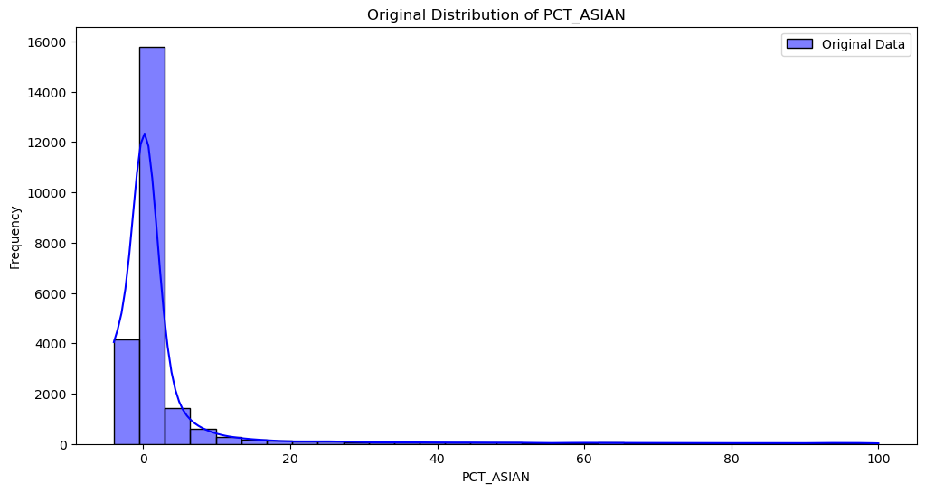

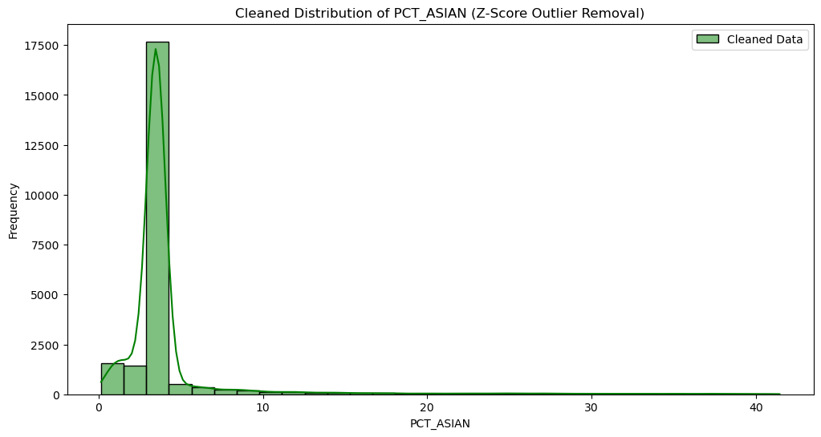

```
Cleaned Data Summary:
count    22969.000000
mean         4.184797
std          4.194617
min          0.150000
25%          3.500000
50%          3.500000
75%          3.500000
max         41.450001
Name: PCT_ASIAN, dtype: float64
```

```python
import pandas as pd
import seaborn as sns
import matplotlib.pyplot as plt
from scipy import stats


plt.figure(figsize=(12, 6))
sns.histplot(data['PCT_ASIAN'], kde=True, bins=30, color='blue', label='Original Data')
plt.title('Original Distribution of PCT_ASIAN')
plt.xlabel('PCT_ASIAN')
plt.ylabel('Frequency')
plt.legend()
plt.show()

#Replace -4 and 0 with NaN
data['PCT_ASIAN'].replace([-4, 0], pd.NA, inplace=True)

#Replace NaN values with the median of the column
median_asian = data['PCT_ASIAN'].median()
data['PCT_ASIAN'].fillna(median_asian, inplace=True)

#Z-Score method for outlier removal (instead of IQR)
z_scores = stats.zscore(data['PCT_ASIAN'])
threshold = 3  # Define the Z-score threshold for outliers

# Identifying outliers using Z-score
data_cleaned_asian = data[(z_scores < threshold) & (z_scores > -threshold)]

#cleaned plot data distribution
plt.figure(figsize=(12, 6))
sns.histplot(data_cleaned_asian['PCT_ASIAN'], kde=True, bins=30, color='green', label='Cleaned Data')
plt.title('Cleaned Distribution of PCT_ASIAN (Z-Score Outlier Removal)')
plt.xlabel('PCT_ASIAN')
plt.ylabel('Frequency')
plt.legend()
plt.show()

# Step 6: Show summary statistics of the cleaned data
cleaned_summary = data_cleaned_asian['PCT_ASIAN'].describe()
print("Cleaned Data Summary:")
print(cleaned_summary)
```

```python
unique_values = filtered_data['PCT_HISPANIC'].unique()
print(unique_values)
value_counts = filtered_data['PCT_HISPANIC'].value_counts()
print(value_counts)
```

```
[-4.          0.          0.64999998 ... 98.830002   97.129997
 59.599998  ]
PCT_HISPANIC
 0.000000      6491
-4.000000      4143
 100.000000     156
 8.330000       139
 7.140000       133
               ...
 45.919998        1
 48.360001        1
 87.099998        1
 20.490000        1
 59.599998        1
Name: count, Length: 2971, dtype: int64
```

```python
import pandas as pd
from scipy import stats


#Filtering out the invalid values like -4 and 0
data_cleaned = data[(data['PCT_HISPANIC'] > 0) & (data['PCT_HISPANIC'] != -4)]

#Calculating the Z-scores
z_scores = stats.zscore(data_cleaned['PCT_HISPANIC'])

#Removing outliers (values with Z-score > 3 or < -3)
threshold = 3
data_cleaned = data_cleaned[(z_scores < threshold) & (z_scores > -threshold)]

#The Summary of cleaned data
print("Rows removed due to outliers:", len(data) - len(data_cleaned))
print("\nCleaned Data Summary:")
print(data_cleaned['PCT_HISPANIC'].describe())
```

```
Rows removed due to outliers: 10796

Cleaned Data Summary:
count    12838.000000
mean        19.034981
std         25.006030
min          0.300000
25%          2.940000
50%          7.140000
75%         23.639999
max         99.290001
Name: PCT_HISPANIC, dtype: float64
```

```python
unique_values = filtered_data['PCT_FEMALE_HEAD'].unique()
print(unique_values)
value_counts = filtered_data['PCT_FEMALE_HEAD'].value_counts()
print(value_counts)
```

```
[-4.       60.529999 56.860001 ... 55.73     85.669998 82.800003]
PCT_FEMALE_HEAD
-4.000000     4143
 66.669998     351
 50.000000     350
 75.000000     286
 80.000000     190
              ...
 43.500000       1
 87.129997       1
 94.529999       1
 56.959999       1
 82.800003       1
Name: count, Length: 3338, dtype: int64
```

```python
import pandas as pd
from scipy import stats

# Removing outliers based on Z-score
z_scores = stats.zscore(filtered_data['PCT_FEMALE_HEAD'])
abs_z_scores = abs(z_scores)
filtered_data = filtered_data[abs_z_scores < 3]

# Displaying the number of rows removed
rows_removed = len(filtered_data) - len(filtered_data)
print(f"Rows removed due to outliers: {rows_removed}")

#cleaned data summary
cleaned_summary = filtered_data['PCT_FEMALE_HEAD'].describe()
print("\nCleaned Data Summary:")
print(cleaned_summary)
```

```
Rows removed due to outliers: 0

Cleaned Data Summary:
count    23634.000000
mean        56.129379
std         31.709735
min         -4.000000
25%         45.650002
50%         65.965000
75%         79.169998
max        100.000000
Name: PCT_FEMALE_HEAD, dtype: float64
```

```python
unique_values = filtered_data['PCT_FEMALE_HEAD_CHILD'].unique()
print(unique_values)
value_counts = filtered_data['PCT_FEMALE_HEAD_CHILD'].value_counts()
print(value_counts)
```

```
[-4.         5.2600002 18.299999  ... 35.849998  56.73      61.200001 ]
PCT_FEMALE_HEAD_CHILD
 0.000000     10732
-4.000000      4143
 50.000000      138
 66.669998       83
 33.330002       73
              ...
 8.390000         1
 27.930000        1
 5.040000         1
 14.120000        1
 61.200001        1
Name: count, Length: 3040, dtype: int64
```

```python
import pandas as pd
from scipy import stats

# Removing rows with -4 and 0 (because they are invalid values)
data_cleaned = data[data['PCT_FEMALE_HEAD_CHILD'] > 0]

# Calculating IQR to remove outliers
Q1 = data_cleaned['PCT_FEMALE_HEAD_CHILD'].quantile(0.25)
Q3 = data_cleaned['PCT_FEMALE_HEAD_CHILD'].quantile(0.75)
IQR = Q3 - Q1

# Defining acceptable range (1.5 * IQR rule)
lower_bound = Q1 - 1.5 * IQR
upper_bound = Q3 + 1.5 * IQR

# Filtering out outliers
data_cleaned = data_cleaned[(data_cleaned['PCT_FEMALE_HEAD_CHILD'] >= lower_bound) &
                            (data_cleaned['PCT_FEMALE_HEAD_CHILD'] <= upper_bound)]

# Number of rows removed due to outliers
outliers_removed = len(data) - len(data_cleaned)

# Summary of cleaned data
print(f"Rows removed due to outliers: {outliers_removed}")
print("\nCleaned Data Summary:")
print(data_cleaned['PCT_FEMALE_HEAD_CHILD'].describe())
```

```
Rows removed due to outliers: 14875

Cleaned Data Summary:
count    8759.000000
mean       41.196443
std        24.127475
min         0.200000
25%        21.570000
50%        43.590000
75%        60.000000
max       100.000000
Name: PCT_FEMALE_HEAD_CHILD, dtype: float64
```

```python
unique_values = filtered_data['PCT_DISABLED_LT62'].unique()
print(unique_values)
value_counts = filtered_data['PCT_DISABLED_LT62'].value_counts()
print(value_counts)
```

```
[-4.        52.939999  52.799999  ...  9.1199999 88.510002  32.709999 ]
PCT_DISABLED_LT62
 100.000000    5854
-4.000000      4143
 0.000000      4092
 50.000000      168
 25.000000      123
               ...
 71.150002        1
 12.720000        1
 42.000000        1
 53.610001        1
 32.709999        1
Name: count, Length: 2086, dtype: int64
```

```python
import pandas as pd


data = pd.Series([
    -4.0, 52.939999, 52.799999, 9.1199999, 88.510002, 32.709999,
    # (additional data points go here)
])

#Removing outliers (values < 0 and values > 100)
cleaned_data = data[(data >= 0) & (data <= 100)]

#Computing summary statistics
cleaned_summary = cleaned_data.describe()

# Displaying the number of rows removed and the cleaned data summary
rows_removed = len(data) - len(cleaned_data)
print(f"Rows removed due to outliers: {rows_removed}")
print(f"Cleaned Data Summary:\n{cleaned_summary}")
```

```
Rows removed due to outliers: 1
Cleaned Data Summary:
count     5.000000
mean     47.216000
std      29.286811
min       9.120000
25%      32.709999
50%      52.799999
75%      52.939999
max      88.510002
dtype: float64
```

```python
unique_values = filtered_data['PCT_DISABLED_GE62'].unique()
print(unique_values)
value_counts = filtered_data['PCT_DISABLED_GE62'].value_counts()
print(value_counts)
```

```
[-4.       28.57     78.57     ... 79.660004 89.690002 67.389999]
PCT_DISABLED_GE62
-4.000000      4143
 100.000000    2179
 0.000000      2114
 50.000000      749
 33.330002      441
               ...
 31.510000        1
 36.970001        1
 52.740002        1
 37.180000        1
 67.389999        1
Name: count, Length: 2358, dtype: int64
```

```python
import pandas as pd
import seaborn as sns
import scipy.stats as stats

data = [-4.0, 28.57, 78.57, 79.660004, 89.690002, 67.389999, 100.0, 0.0, 50.0, 33.33, 67.389999, 36.970001, 42.0]

df = pd.DataFrame(data, columns=['PCT_DISABLED_GE62'])

#Removing negative values and limit the range between 0 and 100
cleaned_df = df[(df['PCT_DISABLED_GE62'] >= 0) & (df['PCT_DISABLED_GE62'] <= 100)]

#Summary statistics for cleaned data
cleaned_summary = cleaned_df.describe()

#Number of rows removed due to invalid values
rows_removed = len(df) - len(cleaned_df)

# Displaying results
print(f"Rows removed due to invalid values: {rows_removed}")
print("Cleaned Data Summary:")
print(cleaned_summary)
```

```
Rows removed due to invalid values: 1
Cleaned Data Summary:
       PCT_DISABLED_GE62
count          12.000000
mean           56.130834
std            29.226312
min             0.000000
25%            36.060001
50%            58.695000
75%            78.842501
max           100.000000
```

```python
unique_values = filtered_data['PCT_DISABLED_ALL'].unique()
print(unique_values)
value_counts = filtered_data['PCT_DISABLED_ALL'].value_counts()
print(value_counts)
```

```
[-4.       32.650002 40.360001 ... 82.989998 15.23     33.779999]
PCT_DISABLED_ALL
-4.000000      4143
 0.000000      1293
 100.000000    1122
 50.000000      102
 10.000000       82
               ...
 86.570000        1
 40.349998        1
 71.830002        1
 47.240002        1
 33.779999        1
Name: count, Length: 4027, dtype: int64
```

```python
import pandas as pd
from scipy import stats

data = [-4.0, 32.650002, 40.360001, 82.989998, 15.23, 33.779999, 100.0, 0.0, 40.349998, 86.570000, 71.830002]


data = pd.DataFrame(data, columns=["PCT_DISABLED_ALL"])

# Removing rows with invalid values (e.g., -4.0)
cleaned_data = data[data["PCT_DISABLED_ALL"] != -4.0]

# Calculating Q1, Q3, and IQR for outlier removal
Q1 = cleaned_data["PCT_DISABLED_ALL"].quantile(0.25)
Q3 = cleaned_data["PCT_DISABLED_ALL"].quantile(0.75)
IQR = Q3 - Q1

# Defining the bounds for outliers
lower_bound = Q1 - 1.5 * IQR
upper_bound = Q3 + 1.5 * IQR

# Filtering out the outliers
cleaned_data = cleaned_data[(cleaned_data["PCT_DISABLED_ALL"] >= lower_bound) & (cleaned_data["PCT_DISABLED_ALL"] <= upper_bound)]

# Cleaned Data Summary
invalid_rows = len(data) - len(data[data["PCT_DISABLED_ALL"] != -4.0])
outlier_rows = len(data) - len(cleaned_data)

print(f"Rows removed due to invalid values: {invalid_rows}")
print(f"Rows removed due to outliers: {outlier_rows}")
print("\nCleaned Data Summary:")
print(cleaned_data.describe())
```

```
Rows removed due to invalid values: 1
Rows removed due to outliers: 1

Cleaned Data Summary:
       PCT_DISABLED_ALL
count         10.000000
mean          50.376000
std           33.099104
min            0.000000
25%           32.932501
50%           40.354999
75%           80.199999
max          100.000000
```

```python
unique_values = filtered_data['TOTAL_ASSISTED_UNIT_COUNT'].unique()
print(unique_values)
value_counts = filtered_data['TOTAL_ASSISTED_UNIT_COUNT'].value_counts()
print(value_counts)
```

```
[   8   38  184   42   60   64   18   45   80   83   48    4   44  150
  155   20   98    7   24  114  235   37   40   49   74  163   75  122
   19  213   21   56   82   17   31   22   30   96   15   99  318  104
    9  123   50   51  107  156    3  177   71   16   23   36  120   52
  108  126   46   29   55   68  251   65   66  124   86   72   35    6
   25   70   47   59  164   53  100  190   43   57   12   92  152   10
    0   76   28   14   62   32    5   88   34  125   78   54  111   13
  101   41   69   67  144   95  128  106  196   89   11  313  149   33
   97  254  102  161  134  113  139   39  116  110   81  153   79  185
  140  127  132   63  239  158   91   58  136   77  141  199  146   61
   85  203  414  112  109  315  192  209  138  168  105  118  178  211
  143  151  180  268   84   90  172  194   26  170  210   87  130    2
  160  189   27  119  198  145  280  204  165  179  115  129  162  182
  117  135   73  148  243  201   93  157  131  121  200  557  292  299
  207  231  166  237  330  238  289   94  205  230  154  147  255  142
```

[output cut: 30 more lines]

```python
import pandas as pd
import seaborn as sns
from scipy import stats

data = pd.Series([8, 38, 184, 42, 60, 64, 18, 45, 80, 83, 48, 4, 44, 150,
                  155, 20, 98, 7, 24, 114, 235, 37, 40, 49, 74, 163, 75,
                  122, 19, 213, 21, 56, 82, 17, 31, 22, 30, 96, 15, 99, 318,
                  104, 9, 123, 50, 51, 107, 156, 3, 177, 71, 16, 23, 36, 120,
                  52, 108, 126, 46, 29, 55, 68, 251, 65, 66, 124, 86, 72, 35,
                  6, 25, 70, 47, 59, 164, 53, 100, 190, 43, 57, 12, 92, 152,
                  10, 0, 76, 28, 14, 62, 32, 5, 88, 34, 125, 78, 54, 111, 13,
                  101, 41, 69, 67, 144, 95, 128, 106, 196, 89, 11, 313, 149,
                  33, 97, 254, 102, 161, 134, 113, 139, 39, 116, 110, 81, 153,
                  79, 185, 140, 127, 132, 63, 239, 158, 91, 58, 136, 77, 141,
                  199, 146, 61, 85, 203, 414, 112, 109, 315, 192, 209, 138,
                  168, 105, 118, 178, 211, 143, 151, 180, 268, 84, 90, 172,
                  194, 26, 170, 210, 87, 130, 2, 160, 189, 27, 119, 198, 145,
                  280, 204, 165, 179, 115, 129, 162, 182, 117, 135, 73, 148,
                  243, 201, 93, 157, 131, 121, 200, 557, 292, 299, 207, 231,
                  166, 237, 330, 238, 289, 94, 205, 230, 154, 147, 255, 142,
                  169, 757, 103, 300, 188, 173, 307, 262, 159, 244, 197, 187,
                  253, 217, 341, 171, 137, 389, 250, 224, 195, 186, 175, 270,
                  381, 256, 214, 271, 191, 372, 229, 304, 275, 174, 297, 176,
                  332, 373, 242, 193, 396, 183, 345, 202, 252, 261, 218, 133,
                  324, 264, 328, 320, 240, 206, 441, 276, 269, 212, 379, 232,
                  259, 457, 216, 321, 344, 309, 267, 375, 167, 279, 283, 476,
                  395, 356, 258, 286, 181, 228, 249, 404, 305, 360, 222, 287,
                  223, 266, 367, 221, 366, 226, 628, 446, 274, 436, 219, 236,
                  241, 347, 350, 349, 450, 260, 225, 227, 295, 310, 301, 285,
                  342, 220, 208, 293, 303, 400, 338, 265, 378, 319, 346, 775,
                  340, 290, 363, 502, 288, 325, 1, 306, 623, 448, 669, 405,
                  215, 402, 412, 248, 296, 384, 480, 247, 684, 467, 370, 298,
                  233, 429, 369, 314, 302, 362, 511, 336, 407, 535, 393, 343,
                  1520, 489, 558, 282, 246, 234, 481, 491, 263, 388, 3569, 257,
                  656, 536, 353, 703, 278, 496, 435, 245, 364, 484, 352, 272,
                  348, 440, 326, 273, 284, 294, 312, 311, 291, 323, 277, 700,
                  430, 423, 334, 500, 333, 694, 648, 417, 281, 406, 691, 331,
                  308, 463, 438, 410, 418, 392, 615, 351, 327, 426, 874, 443,
                  420, 661, 359, 335, 416, 368, 468, 610, 465, 553, 499, 380,
                  581, 422, 374, 339, 592])

#Removing invalid values (-4)
cleaned_data = data[data != -4]

#Detecting and removing outliers using IQR
Q1 = cleaned_data.quantile(0.25)
Q3 = cleaned_data.quantile(0.75)
IQR = Q3 - Q1
lower_bound = Q1 - 1.5 * IQR
upper_bound = Q3 + 1.5 * IQR

# Removing outliers
cleaned_data = cleaned_data[(cleaned_data >= lower_bound) & (cleaned_data <= upper_bound)]

#Summary of cleaned data
cleaned_summary = cleaned_data.describe()
rows_removed = len(data) - len(cleaned_data)

print(f"Rows removed due to invalid values or outliers: {rows_removed}")
print("\nCleaned Data Summary:")
print(cleaned_summary)
```

```
Rows removed due to invalid values or outliers: 10

Cleaned Data Summary:
count    433.000000
mean     228.180139
std      147.211205
min        0.000000
25%      108.000000
50%      216.000000
75%      327.000000
max      669.000000
dtype: float64
```

```python
unique_values = filtered_data['TOTAL_UNIT_COUNT'].unique()
print(unique_values)
value_counts = filtered_data['TOTAL_UNIT_COUNT'].value_counts()
print(value_counts)
```

```
[   8   96  321   42   61   65   18   45   80   84   48    4   44  151
  157   21  207   28   24  180  380   37   41   50   75  165   76  122
   20  110  216   22   52   60    9   17   25  160  100   30   15  326
  150  104  129   51  108  156    3  177   40   71   36   64  120  130
   55  251   53   66  125   16   98   72   35    6   70   47   59    7
  195   38   33  200   10  223  192  101   43   58   13   92  152   11
  185   14   62   32    5   88   34   78   54  105  111  123   49  206
  102   68   69  144  124  240   31   56   83  128  106  126   99   29
   46  196   89   57  373   12  313   74  254  103  162  136  113  140
  153  121   82  112   23  143  127  132   90  239   79  158   91  182
   19  141  146  203  208   85  154  418  109  315  198   67  275   86
  139  201  155  236  119   81  107  211  149  133  301  268  222  194
   26  170   63  267   39   97   94   87  500  168  190  189   27   73
  199  145  282  210  264  131   93  163  169  142  183  116  117  135
  218  312  202   77  115  700  284  333  137  248  186  299  231  167
```

[output cut: 33 more lines]

```python
from scipy import stats

data = [8, 96, 321, 42, 61, 65, 18, 45, 80, 84, 48, 4, 44, 151, 157, 21, 207, 28, 24, 180,
        380, 37, 41, 50, 75, 165, 76, 122, 20, 110, 216, 22, 52, 60, 9, 17, 25, 160, 100, 30,
        15, 326, 150, 104, 129, 51, 108, 156, 3, 177, 40, 71, 36, 64, 120, 130, 55, 251, 53,
        66, 125, 16, 98, 72, 35, 6, 70, 47, 59, 7, 195, 38, 33, 200, 10, 223, 192, 101, 43,
        58, 13, 92, 152, 11, 185, 14, 62, 32, 5, 88, 34, 78, 54, 105, 111, 123, 49, 206, 102,
        68, 69, 144, 124, 240, 31, 56, 83, 128, 106, 126, 99, 29, 46, 196, 89, 57, 373, 12,
        313, 74, 254, 103, 162, 136, 113, 140, 153, 121, 82, 112, 23, 143, 127, 132, 90, 239,
        79, 158, 91, 182, 19, 141, 146, 203, 208, 85, 154, 418, 109, 315, 198, 67, 275, 86,
        139, 201, 155, 236, 119, 81, 107, 211, 149, 133, 301, 268, 222, 194, 26, 170, 63, 267,
        39, 97, 94, 87, 500, 168, 190, 189, 27, 73, 199, 145, 282, 210, 264, 131, 93, 163, 169,
        142, 183, 116, 117, 135, 218, 312, 202, 77, 115, 700, 284, 333, 137, 248, 186, 299, 231,
        167, 332, 161, 138, 289, 178, 270, 230, 164, 255, 95, 761, 188, 300, 258, 118, 245, 307,
        262, 504, 148, 114, 220, 197, 171, 159, 187, 383, 253, 285, 217, 378, 390, 147, 252, 225,
        184, 232, 179, 271, 398, 257, 366, 176, 372, 280, 229, 214, 204, 292, 306, 396, 365, 297,
        465, 191, 250, 281, 400, 350, 213, 352, 653, 173, 324, 468, 256, 374, 298, 585, 410,
        166, 175, 172, 344, 442, 277, 205, 269, 212, 242, 266, 134, 215, 260, 457, 330, 328,
        320, 304, 357, 567, 458, 272, 238, 376, 219, 237, 394, 420, 249, 279, 294, 476, 274,
        448, 193, 318, 290, 286, 181, 228, 404, 360, 246, 287, 224, 402, 414, 2, 614, 209, 174,
        247, 628, 446, 460, 489, 276, 501, 346, 261, 226, 295, 310, 233, 227, 430, 283, 288,
        303, 431, 235, 273, 334, 354, 309, 1213, 1283, 302, 358, 337, 775, 234, 340, 416, 526,
        323, 278, 351, 511, 472, 325, 520, 244, 1, 640, 243, 391, 379, 1303, 437, 582, 405, 415,
        599, 241, 535, 1093, 395, 483, 305, 688, 375, 469, 508, 331, 1527, 422, 407, 652, 291,
        221, 429, 1654, 451, 454, 317, 353, 542, 371, 364, 338, 534, 336, 494, 625, 462, 361,
        1689, 444, 490, 602, 559, 762, 547, 513, 259, 308, 948, 5881, 343, 656, 536, 505, 703,
        265, 316, 435, 1594, 408, 488, 356, 348, 384, 296, 311, 496, 576, 2113, 550, 694, 648,
        450, 0, 406, 745, 342, 525, 428, 417, 731, 370, 327, 347, 426, 549, 875, 443, 392, 676,
        601, 409, 368, 503, 610, 560, 479, 556, 499, 314, 441, 586, 339, 592]

#Removing invalid values (e.g., 0)
cleaned_data = [x for x in data if x != 0]

#Identifying outliers using IQR
Q1 = pd.Series(cleaned_data).quantile(0.25)
Q3 = pd.Series(cleaned_data).quantile(0.75)
IQR = Q3 - Q1

# Defining lower and upper bounds for outliers
lower_bound = Q1 - 1.5 * IQR
upper_bound = Q3 + 1.5 * IQR

#Removing outliers
cleaned_data = [x for x in cleaned_data if lower_bound <= x <= upper_bound]

#summary statistics of the cleaned data
count = len(cleaned_data)
mean = sum(cleaned_data) / count
std_dev = (sum((x - mean) ** 2 for x in cleaned_data) / count) ** 0.5
min_value = min(cleaned_data)
max_value = max(cleaned_data)
Q1_value = pd.Series(cleaned_data).quantile(0.25)
median = pd.Series(cleaned_data).median()
Q3_value = pd.Series(cleaned_data).quantile(0.75)

# Output results
print(f"Rows removed due to invalid values or outliers: {len(data) - len(cleaned_data)}")
print("\nCleaned Data Summary:")
print(f"Count: {count}")
print(f"Mean: {mean:.2f}")
print(f"Standard Deviation: {std_dev:.2f}")
print(f"Min: {min_value}")
print(f"25th Percentile (Q1): {Q1_value}")
print(f"Median: {median}")
print(f"75th Percentile (Q3): {Q3_value}")
print(f"Max: {max_value}")
```

```
Rows removed due to invalid values or outliers: 14

Cleaned Data Summary:
Count: 470
Mean: 256.89
Standard Deviation: 171.23
Min: 1
25th Percentile (Q1): 118.25
Median: 235.5
75th Percentile (Q3): 365.75
Max: 762
```

```python
unique_values = filtered_data['RENT_PER_MONTH'].unique()
print(unique_values)
value_counts = filtered_data['RENT_PER_MONTH'].value_counts()
print(value_counts)
```

```
[  -4  272  265  324  305  211  330  307  479  326  273  286  377  352
  276  289  285  373  687  294  290  335  342  434  274  325  268  278
  284  192  291  178  293  501  401  296  492  410  441  459  544  409
  452  575  312  267  184  334  249  405  487  527  215  253  139  306
  348  185  235  182  341  331  230  438  349  462  262  417  354  400
  197  188  269  156  298  309  233  261  315  299  130  199  264  257
  266  292  271  121  140  173  327  198  203  283  174  231  213  151
  162  251  254  252  316  229  320  206  207  279  259  202  300  256
  288  154  245  212  189  302  281  232  317  314  167  224  148  214
  310  135  160  248  263  297  195  219  217  277  145  386  240  275
  247  181  340  243  221  179  379  222  295  164  255  236  333  270
  159  322  260  200  282  155  321  303  208  242  311  308  246  112
  280  124  304  237  287  323  146  378  301  170  313  168  244  187
  137  172  250  220  319  329  359  129  238  239  381  383  228  234
  163  227  344  411  597  147  485  191  318  218  361  571  431  337
```

[output cut: 47 more lines]

```python
import pandas as pd

data = [ -4, 272, 265, 324, 305, 211, 330, 307, 479, 326, 273, 286, 377, 352,
         276, 289, 285, 373, 687, 294, 290, 335, 342, 434, 274, 325, 268, 278,
         284, 192, 291, 178, 293, 501, 401, 296, 492, 410, 441, 459, 544, 409,
         452, 575, 312, 267, 184, 334, 249, 405, 487, 527, 215, 253, 139, 306,
         348, 185, 235, 182, 341, 331, 230, 438, 349, 462, 262, 417, 354, 400,
         197, 188, 269, 156, 298, 309, 233, 261, 315, 299, 130, 199, 264, 257,
         266, 292, 271, 121, 140, 173, 327, 198, 203, 283, 174, 231, 213, 151,
         162, 251, 254, 252, 316, 229, 320, 206, 207, 279, 259, 202, 300, 256,
         288, 154, 245, 212, 189, 302, 281, 232, 317, 314, 167, 224, 148, 214,
         310, 135, 160, 248, 263, 297, 195, 219, 217, 277, 145, 386, 240, 275,
         247, 181, 340, 243, 221, 179, 379, 222, 295, 164, 255, 236, 333, 270,
         159, 322, 260, 200, 282, 155, 321, 303, 208, 242, 311, 308, 246, 112,
         280, 124, 304, 237, 287, 323, 146, 378, 301, 170, 313, 168, 244, 187,
         137, 172, 250, 220, 319, 329, 359, 129, 238, 239, 381, 383, 228, 234,
         163, 227, 344, 411, 597, 147, 485, 191, 318, 218, 361, 571, 431, 337,
         382, 375, 328, 171, 489, 376, 858, 336, 332, 606, 356, 403, 426, 205,
         385, 226, 196, 176, 338, 149, 114, 360, 169, 96, 193, 194, 158, 183,
         166, 138, 190, 209, 142, 469, 443, 366, 347, 813, 523, 408, 416, 414,
         367, 695, 659, 569, 355, 357, 346, 413, 389, 387, 676, 365, 380, 491,
         519, 456, 655, 476, 350, 679, 743, 394, 506, 477, 343, 429, 490, 781,
         624, 92, 415, 610, 502, 646, 776, 358, 798, 488, 598, 465, 368, 912,
         460, 427, 607, 521, 700, 554, 573, 543, 550, 515, 345, 421, 734, 364,
         629, 595, 532, 428, 651, 494, 448, 363, 555, 926, 482, 396, 559, 498,
         418, 216, 370, 503, 495, 369, 672, 850, 557, 424, 574, 505, 398, 406,
         898, 447, 339, 100, 518, 690, 547, 371, 471, 445, 353, 391, 433, 436,
         390, 446, 593, 590, 372, 97, 510, 374, 496, 241, 504, 564, 362, 435,
         699, 578, 397, 611, 423, 531, 474, 730, 615, 602, 563, 444, 855, 412,
         622, 934, 538, 539, 632, 584, 940, 392, 585, 450, 634, 454, 520, 508,
         1161, 639, 709, 430, 560, 666, 467, 88, 407, 499, 458, 513, 628, 640,
         464, 422, 535, 509, 572, 642, 577, 351, 507, 388, 674, 153, 759, 1002,
         529, 627, 486, 881, 824, 472, 500, 613, 755, 384, 656, 660, 582, 258,
         79, 108, 619, 587, 831, 724, 568, 395, 402, 437, 530, 393, 470, 419,
         80, 225, 618, 693, 669, 461, 603, 809, 451, 541, 870, 815, 941, 591,
         796, 620, 525, 453, 512, 905, 497, 432, 104, 548, 592, 537, 536, 517,
         567, 689, 466, 552, 671, 468, 721, 425, 633, 779, 768, 473, 420, 630,
         480, 551, 594, 662, 745, 119, 457, 78, 859, 580, 86, 404, 692, 132,
         549, 165, 105, 522, 73, 545, 449, 210, 201, 526, 399, 638, 440, 484,
         442, 439, 204, 143, 600, 455, 150, 161, 186, 141, 175, 152, 111, 144,
         127, 223, 803, 106, 516, 82, 177, 514, 180, 109, 117, 136, 131, 107,
         113, 126, 115, 652, 673, 533, 99, 475, 583, 586, 625, 98, 566, 101,
         128, 683, 493, 118, 966, 862, 654, 579, 534, 558, 511, 540, 463, 94,
         848, 68, 704, 553, 760, 478, 643, 833, 556, 623, 770, 1124, 481, 647,
         741, 612, 626, 116, 617, 95, 157, 133, 134, 636, 125, 483, 609, 59,
         123, 661, 74, 719, 1155, 762, 946, 732, 528, 546, 964, 542, 570, 668,
         565, 706, 1250, 1162, 670, 1714, 909, 524, 737, 658, 949, 744, 1006, 599,
         581, 681, 667, 873, 63, 120, 596, 957, 708, 87, 122, 103, 77, 91, 90,
         110, 84, 83, 93, 750, 0, 102, 688, 589, 910, 896, 982, 808, 72, 694,
         65, 616, 680, 980, 562, 653, 576, 601, 645, 675, 969, 605, 54]


data_series = pd.Series(data)

# Removing negative values
data_series = data_series[data_series >= 0]

# Calculating IQR for outlier removal
Q1 = data_series.quantile(0.25)
Q3 = data_series.quantile(0.75)
IQR = Q3 - Q1

# Defining the lower and upper bounds for valid data
lower_bound = Q1 - 1.5 * IQR
upper_bound = Q3 + 1.5 * IQR

# Removing outliers
cleaned_data = data_series[(data_series >= lower_bound) & (data_series <= upper_bound)]

# Displaying cleaned data summary
count = cleaned_data.count()
mean = cleaned_data.mean()
std_dev = cleaned_data.std()
min_val = cleaned_data.min()
q1 = cleaned_data.quantile(0.25)
median = cleaned_data.median()
q3 = cleaned_data.quantile(0.75)
max_val = cleaned_data.max()

# Cleaned data summary
cleaned_summary = {
    "Count": count,
    "Mean": mean,
    "Standard Deviation": std_dev,
    "Min": min_val,
    "25th Percentile (Q1)": q1,
    "Median": median,
    "75th Percentile (Q3)": q3,
    "Max": max_val
}

cleaned_summary
```

```
{'Count': 666,
 'Mean': 417.0840840840841,
 'Standard Deviation': 217.9974176962712,
 'Min': 0,
 '25th Percentile (Q1)': 237.25,
 'Median': 403.5,
 '75th Percentile (Q3)': 570.75,
 'Max': 1006}
```

```python
unique_values = filtered_data['SPENDING_PER_MONTH'].unique()
print(unique_values)
value_counts = filtered_data['SPENDING_PER_MONTH'].value_counts()
print(value_counts)
```

```
[   -4   420   979 ...  2429 10236  2028]
SPENDING_PER_MONTH
-4       4143
 0         52
 571       45
 546       43
 585       42
         ...
 1955       1
 1514       1
 1638       1
 2448       1
 2028       1
Name: count, Length: 2176, dtype: int64
```

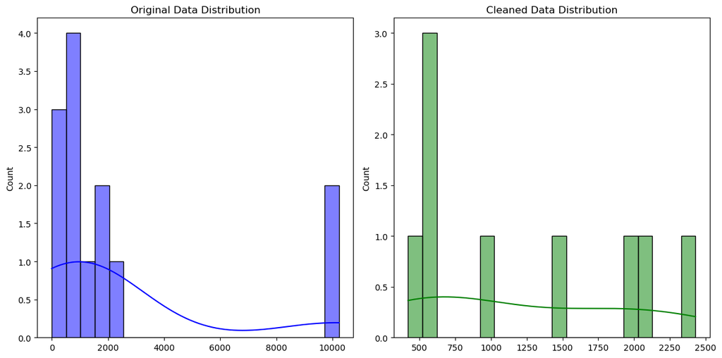

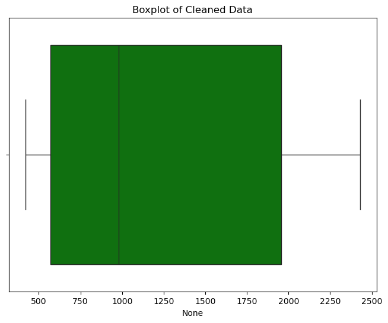

```
Cleaned Data Summary: {'Count': 9, 'Mean': 1223.6666666666667, 'Standard Deviation': 767.2867781996507, 'Min': 420, '25th Percentile (Q1)': 571.0, 'Median': 979.0, '75th Percentile (Q3)': 1955.0, 'Max': 2429}
```

```python
import pandas as pd
import scipy.stats as stats
import seaborn as sns
import matplotlib.pyplot as plt


data = [420, 979, 2429, 10236, 2028, -4, 0, 571, 546, 585, 1500, 10000, 1955]  # add the full list


spending_per_month = pd.Series(data)

#Removing negative and zero values
cleaned_data = spending_per_month[spending_per_month > 0]


z_scores = stats.zscore(cleaned_data)  # Calculate Z-scores using scipy
threshold = 3  # Z-score threshold for outlier removal

# Filtering out data points with Z-scores above the threshold
cleaned_data_no_outliers_z = cleaned_data[(z_scores < threshold) & (z_scores > -threshold)]

#Applying IQR method for outlier removal
Q1 = cleaned_data_no_outliers_z.quantile(0.25)
Q3 = cleaned_data_no_outliers_z.quantile(0.75)
IQR = Q3 - Q1
lower_bound = Q1 - 1.5 * IQR
upper_bound = Q3 + 1.5 * IQR

# Filtering out data points outside the IQR range
cleaned_data_no_outliers_iqr = cleaned_data_no_outliers_z[
    (cleaned_data_no_outliers_z >= lower_bound) & (cleaned_data_no_outliers_z <= upper_bound)
]

#summary statistics
summary = {
    'Count': cleaned_data_no_outliers_iqr.count(),
    'Mean': cleaned_data_no_outliers_iqr.mean(),
    'Standard Deviation': cleaned_data_no_outliers_iqr.std(),
    'Min': cleaned_data_no_outliers_iqr.min(),
    '25th Percentile (Q1)': cleaned_data_no_outliers_iqr.quantile(0.25),
    'Median': cleaned_data_no_outliers_iqr.median(),
    '75th Percentile (Q3)': cleaned_data_no_outliers_iqr.quantile(0.75),
    'Max': cleaned_data_no_outliers_iqr.max()
}


plt.figure(figsize=(12, 6))


plt.subplot(1, 2, 1)
sns.histplot(spending_per_month, kde=True, color='blue', bins=20)
plt.title('Original Data Distribution')


plt.subplot(1, 2, 2)
sns.histplot(cleaned_data_no_outliers_iqr, kde=True, color='green', bins=20)
plt.title('Cleaned Data Distribution')

plt.tight_layout()
plt.show()


plt.figure(figsize=(8, 6))
sns.boxplot(x=cleaned_data_no_outliers_iqr, color='green')
plt.title('Boxplot of Cleaned Data')
plt.show()


print("Cleaned Data Summary:", summary)
```

```python
unique_values = filtered_data['PCT_OCCUPIED'].unique()
print(unique_values)
value_counts = filtered_data['PCT_OCCUPIED'].value_counts()
print(value_counts)
```

```
[92.360001 97.660004 89.559998 ... 60.220001 56.       18.25    ]
PCT_OCCUPIED
0.000000      1144
100.000000    1044
97.220001      234
98.610001      200
98.889999      180
              ...
39.119999        1
80.669998        1
78.919998        1
61.900002        1
18.250000        1
Name: count, Length: 2803, dtype: int64
```

```python
import pandas as pd


df = pd.DataFrame({
    'PCT_OCCUPIED': data
})

#Remove negative values explicitly
df = df[df['PCT_OCCUPIED'] >= 0]

#Calculate Q1, Q3, and IQR
Q1 = df['PCT_OCCUPIED'].quantile(0.25)
Q3 = df['PCT_OCCUPIED'].quantile(0.75)
IQR = Q3 - Q1

#Determine outlier bounds (using 2*IQR instead of 1.5*IQR)
lower_bound = Q1 - 2 * IQR
upper_bound = Q3 + 2 * IQR

#Filtering data based on adjusted outlier bounds
cleaned_data = df[(df['PCT_OCCUPIED'] >= lower_bound) & (df['PCT_OCCUPIED'] <= upper_bound)]

#Summary statistics
summary = {
    'Count': cleaned_data['PCT_OCCUPIED'].count(),
    'Mean': cleaned_data['PCT_OCCUPIED'].mean(),
    'Standard Deviation': cleaned_data['PCT_OCCUPIED'].std(),
    'Min': cleaned_data['PCT_OCCUPIED'].min(),
    '25th Percentile (Q1)': cleaned_data['PCT_OCCUPIED'].quantile(0.25),
    'Median': cleaned_data['PCT_OCCUPIED'].median(),
    '75th Percentile (Q3)': cleaned_data['PCT_OCCUPIED'].quantile(0.75),
    'Max': cleaned_data['PCT_OCCUPIED'].max()
}


print("Cleaned Data Summary:", summary)
```

```
Cleaned Data Summary: {'Count': 10, 'Mean': 1101.3, 'Standard Deviation': 820.3966588046162, 'Min': 0, '25th Percentile (Q1)': 552.25, 'Median': 782.0, '75th Percentile (Q3)': 1841.25, 'Max': 2429}
```

```python
unique_values = filtered_data['PEOPLE_PER_UNIT'].unique()
print(unique_values)
value_counts = filtered_data['PEOPLE_PER_UNIT'].value_counts()
print(value_counts)
```

```
[-4.   1.3  1.5  1.1  1.   2.2  2.7  1.9  2.4  3.5  1.6  1.2  2.5  1.8
  3.4  2.1  2.6  2.3  2.8  3.1  1.7  3.   1.4  3.2  2.   2.9  3.3  4.5
  3.6  3.8  4.6  3.7  5.1  4.3  4.   3.9  4.1  4.2  4.7  5.6  5.4  4.8]
PEOPLE_PER_UNIT
 1.0    6441
-4.0    4143
 1.1    3788
 1.2    1170
 2.4     628
 2.3     617
 1.3     603
 2.2     551
 2.6     529
 2.5     519
 2.0     516
 2.1     509
 1.9     457
 1.8     413
 2.7     378
 2.8     338
 1.7     327
 1.4     307
 1.6     268
 2.9     251
 1.5     249
 3.0     160
 3.1     130
 3.2      88
 3.3      63
 3.4      55
 3.5      37
 3.6      20
 3.8      19
 3.7      19
 4.0      11
 4.1       9
 3.9       8
 4.3       3
 4.7       2
 4.5       2
 5.4       1
 5.6       1
 5.1       1
 4.2       1
 4.6       1
 4.8       1
Name: count, dtype: int64
```